# Camp Polk and Rm6 data relationships

Ashley Vizek

2024-09-27

# RM 6 temperature data

- Data can be downloaded from the [Upper Deschutes Watershed Council website](https://www.upperdeschuteswatershedcouncil.org/water-quality/)
- These data are available prior to 2012, however, for the exercise of testing the relationship with Camp Polk data only the last 10 years of data were used.
- The plot below shows the daily mean, max, median, and min.

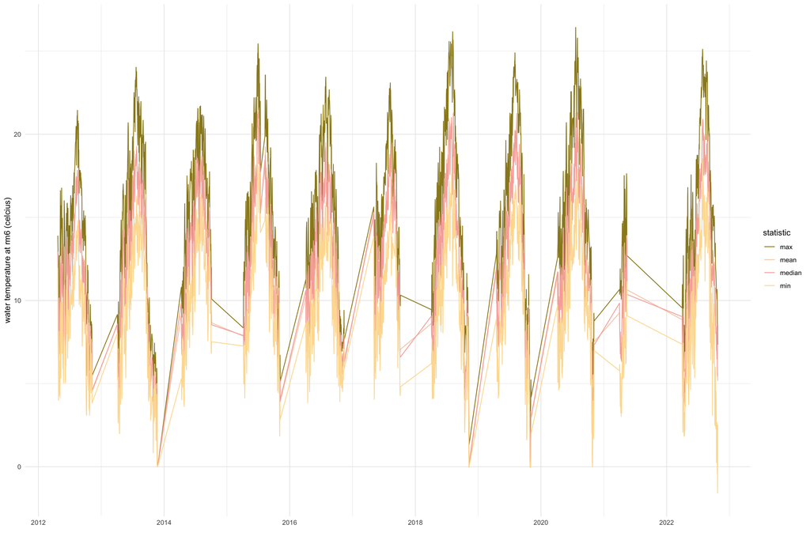

```r
rm6_full_2012_2023 |>
  ggplot(aes(x = date, y = temperature, color = statistic)) +
  geom_line() +
  scale_color_manual(values = colors_small) +
  theme_minimal() +
  labs(x = "",
       y = "water temperature at rm6 (celcius)")
```

# Camp Polk temperature data

- Data can be downloaded from the [OWRD website](https://apps.wrd.state.or.us/apps/sw/hydro_near_real_time/display_hydro_graph.aspx?station_nbr=14076100)
- Temperature data prior to 2015 are not available for download or may not exist. Note that there are also some data gaps.
- The plot below shows the daily mean, max, median, and min.

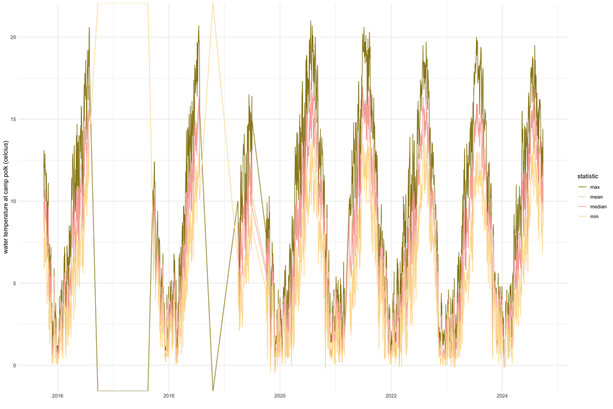

```r
camp_polk |>
  ggplot(aes(x = date, y = temperature, color = statistic)) +
  geom_line() +
  scale_color_manual(values = colors_small) +
  theme_minimal() +
  labs(x = "",
       y = "water temperature at camp polk (celcius)")
```

# Comparing the relationship between water temperature at Camp Polk and RM6

## Visualizing the water temperature relationship

- When visualizing water temperature from the two locations together it looks like they track pretty well, though are limited in the years that overlap

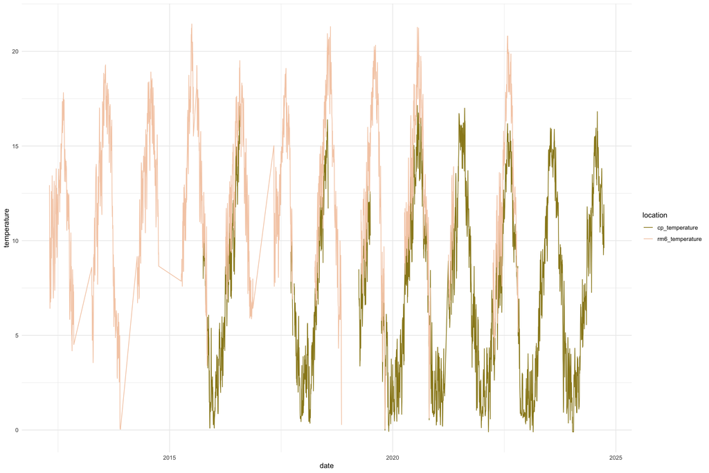

```r
dat_full <- full_join(camp_polk |>
                        rename(cp_temperature = temperature),
                      rm6_full_2012_2023 |>
                        rename(rm6_temperature = temperature))

dat_full |>
  filter(statistic == "mean") |>
  pivot_longer(cols = cp_temperature:rm6_temperature, values_to = "temperature", names_to = "location") |>
  ggplot(aes(x = date, y = temperature, color = location)) +
  geom_line() +
  scale_color_manual(values = colors_small) +
  theme_minimal()
```

## Linear regression

```r
dat_full_mean <- filter(dat_full, statistic == "mean")
# MEAN Regression
split <-rsample::initial_split(dat_full_mean, prop = 0.8)
train <- rsample::training(split)
test <- rsample::testing(split)
cp_rm6_mean_mod <- lm(rm6_temperature ~ date + cp_temperature, data = train)
summary(cp_rm6_mean_mod)
```

```
##
## Call:
## lm(formula = rm6_temperature ~ date + cp_temperature, data = train)
##
## Residuals:
##      Min       1Q   Median       3Q      Max
## -2.81888 -0.35909  0.02146  0.45564  2.49433
##
## Coefficients:
##                  Estimate Std. Error t value Pr(>|t|)
## (Intercept)    -4.868e+00  6.401e-01  -7.606 9.55e-14 ***
## date            2.850e-09  4.044e-10   7.048 4.51e-12 ***
## cp_temperature  1.260e+00  8.431e-03 149.480  < 2e-16 ***
## ---
## Signif. codes:  0 '***' 0.001 '**' 0.01 '*' 0.05 '.' 0.1 ' ' 1
##
## Residual standard error: 0.7053 on 673 degrees of freedom
##   (2269 observations deleted due to missingness)
## Multiple R-squared:  0.9709, Adjusted R-squared:  0.9708
## F-statistic: 1.123e+04 on 2 and 673 DF,  p-value: < 2.2e-16
```

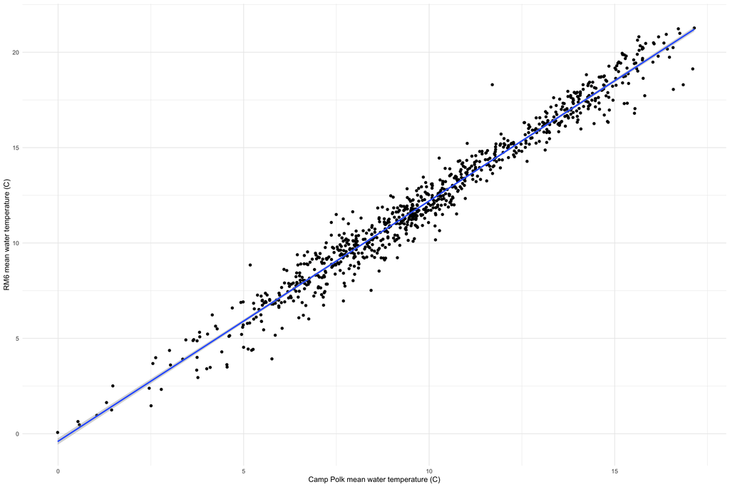

```r
test_predict <- predict(cp_rm6_mean_mod, test)
test_predict_df <- test |>
  mutate(predicted = test_predict)
# evaluate predictions - MAPE of 10% is not bad
# mean(abs((
#   test_predict_df$predicted - test_predict_df$rm6_temperature
# )) / test_predict_df$rm6_temperature)

# plot for mean
ggplot(data = dat_full_mean, aes(x = cp_temperature, y = rm6_temperature)) +
  geom_point() +
  stat_smooth(method = "lm") +
  labs(x = "Camp Polk mean water temperature (C)",
       y = "RM6 mean water temperature (C)") +
  theme_minimal()
```

# Comparing the relationship between discharge at Camp Polk and water temperature at RM6

- The relationship between mean daily flow at Camp Polk and water temperature at RM6 does not track as well

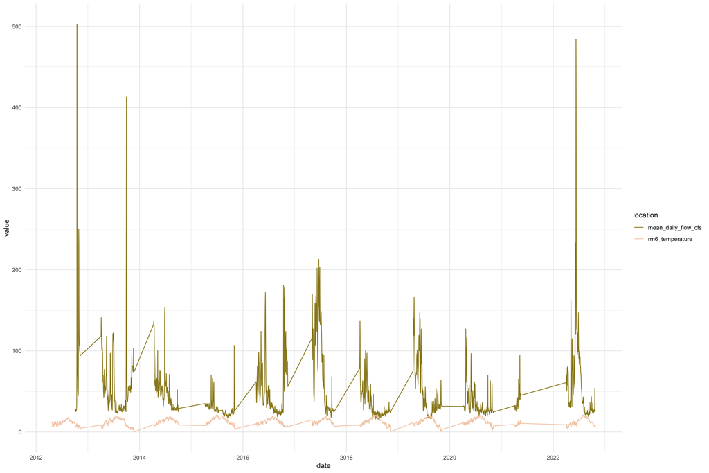

```r
dat_full <- full_join(cp_discharge,
                      rm6_full_2012_2023 |>
                        rename(rm6_temperature = temperature))

dat_full |>
  filter(statistic == "mean") |>
  select(-statistic) |>
  pivot_longer(cols = mean_daily_flow_cfs:rm6_temperature, values_to = "value", names_to = "location") |>
  ggplot(aes(x = date, y = value, color = location)) +
  geom_line() +
  scale_color_manual(values = colors_small) +
  theme_minimal()
```

## Linear regression

- We built a simple linear regression (rm6_temperature ~ date + mean_daily_flow_cfs)
- We used scaled temperatures and flows so they were on the same scale
- This simple model does a very poor job describing this relationship with a very low R2 and more work and covariates (e.g. air temperature etc) would need to go into this

```r
dat_full_mean <- filter(dat_full, statistic == "mean") |>
  mutate(mean_daily_flow_cfs = scale(mean_daily_flow_cfs),
         rm6_temperature = scale(rm6_temperature))
# MEAN Regression
split <-rsample::initial_split(dat_full_mean, prop = 0.8)
train <- rsample::training(split)
test <- rsample::testing(split)
cp_rm6_mean_mod <- lm(rm6_temperature ~ date + mean_daily_flow_cfs, data = train)
summary(cp_rm6_mean_mod)
```

```
##
## Call:
## lm(formula = rm6_temperature ~ date + mean_daily_flow_cfs, data = train)
##
## Residuals:
##      Min       1Q   Median       3Q      Max
## -3.14042 -0.68815  0.05011  0.83465  2.25782
##
## Coefficients:
##                       Estimate Std. Error t value Pr(>|t|)
## (Intercept)         -9.751e-01  4.161e-01  -2.344   0.0192 *
## date                 6.511e-10  2.762e-10   2.358   0.0185 *
## mean_daily_flow_cfs -2.430e-01  2.548e-02  -9.537   <2e-16 ***
## ---
## Signif. codes:  0 '***' 0.001 '**' 0.01 '*' 0.05 '.' 0.1 ' ' 1
##
## Residual standard error: 0.9937 on 1510 degrees of freedom
##   (133 observations deleted due to missingness)
## Multiple R-squared:  0.06067,    Adjusted R-squared:  0.05943
## F-statistic: 48.77 on 2 and 1510 DF,  p-value: < 2.2e-16
```

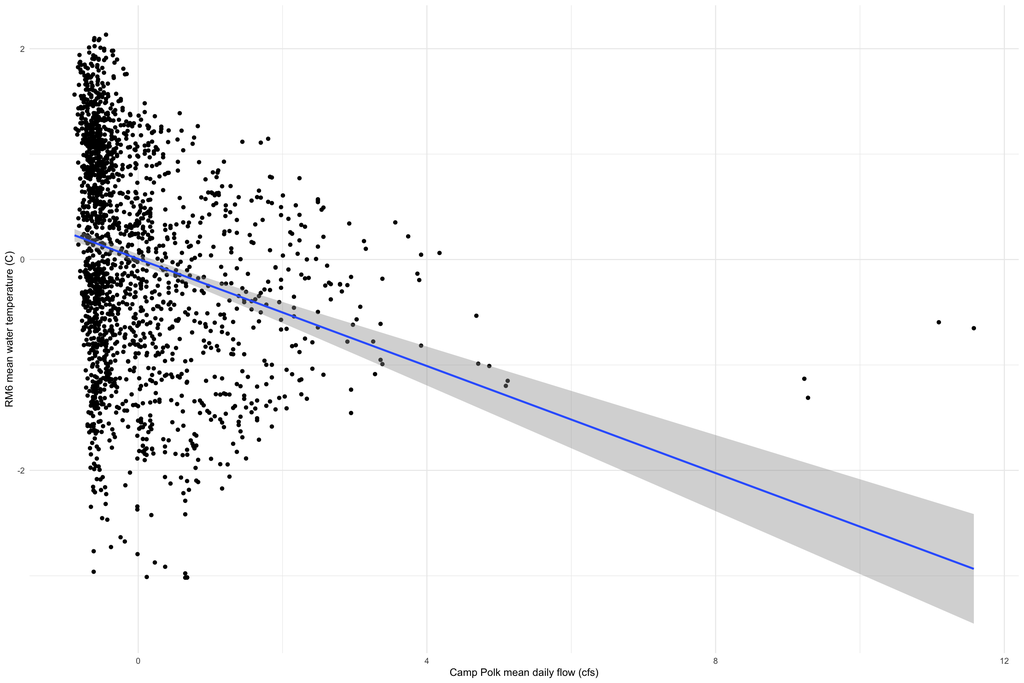

```r
test_predict <- predict(cp_rm6_mean_mod, test)
test_predict_df <- test |>
  mutate(predicted = test_predict)
# evaluate predictions - MAPE of 10% is not bad
# mean(abs((
#   test_predict_df$predicted - test_predict_df$rm6_temperature
# )) / test_predict_df$rm6_temperature)

# plot for mean
ggplot(data = dat_full_mean, aes(x = mean_daily_flow_cfs, y = rm6_temperature)) +
  geom_point() +
  stat_smooth(method = "lm") +
  labs(x = "Camp Polk mean daily flow (cfs)",
       y = "RM6 mean water temperature (C)") +
  theme_minimal()
```

# Comparing the relationship between discharge at Camp Polk and water temperature at Camp Polk

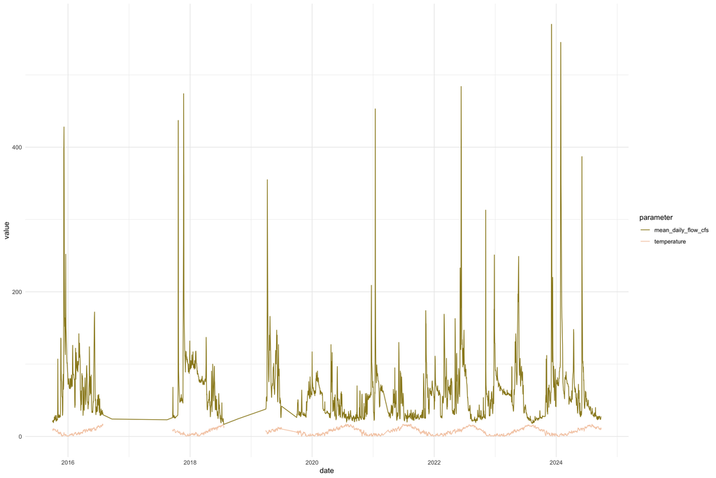

```r
dat_full <- full_join(cp_discharge,
                      camp_polk)

dat_full |>
  filter(statistic == "mean") |>
  select(-statistic) |>
  pivot_longer(cols = mean_daily_flow_cfs:temperature, values_to = "value", names_to = "parameter") |>
  ggplot(aes(x = date, y = value, color = parameter)) +
  geom_line() +
  scale_color_manual(values = colors_small) +
  theme_minimal()
```

## Linear regression

```r
dat_full_mean <- filter(dat_full, statistic == "mean") |>
  mutate(mean_daily_flow_cfs = scale(mean_daily_flow_cfs),
         temperature = scale(temperature))
# MEAN Regression
split <-rsample::initial_split(dat_full_mean, prop = 0.8)
train <- rsample::training(split)
test <- rsample::testing(split)
cp_rm6_mean_mod <- lm(temperature ~ date + mean_daily_flow_cfs, data = train)
summary(cp_rm6_mean_mod)
```

```
##
## Call:
## lm(formula = temperature ~ date + mean_daily_flow_cfs, data = train)
##
## Residuals:
##     Min      1Q  Median      3Q     Max
## -1.7017 -0.8141 -0.0349  0.7622  3.2221
##
## Coefficients:
##                       Estimate Std. Error t value Pr(>|t|)
## (Intercept)         -1.686e+00  4.211e-01  -4.003 6.49e-05 ***
## date                 1.053e-09  2.617e-10   4.025 5.92e-05 ***
## mean_daily_flow_cfs -3.457e-01  2.288e-02 -15.113  < 2e-16 ***
## ---
## Signif. codes:  0 '***' 0.001 '**' 0.01 '*' 0.05 '.' 0.1 ' ' 1
##
## Residual standard error: 0.9417 on 1982 degrees of freedom
##   (4 observations deleted due to missingness)
## Multiple R-squared:  0.1142, Adjusted R-squared:  0.1133
## F-statistic: 127.7 on 2 and 1982 DF,  p-value: < 2.2e-16
```

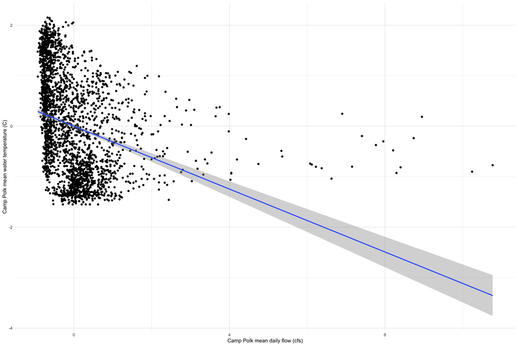

```r
test_predict <- predict(cp_rm6_mean_mod, test)
test_predict_df <- test |>
  mutate(predicted = test_predict)
# evaluate predictions - MAPE of 10% is not bad
# mean(abs((
#   test_predict_df$predicted - test_predict_df$rm6_temperature
# )) / test_predict_df$rm6_temperature)

# plot for mean
ggplot(data = dat_full_mean, aes(x = mean_daily_flow_cfs, y = temperature)) +
  geom_point() +
  stat_smooth(method = "lm") +
  labs(x = "Camp Polk mean daily flow (cfs)",
       y = "Camp Polk mean water temperature (C)") +
  theme_minimal()
```